# Sentiment and Emotion Classification Model Training

Using dataset from kaggle consisting of `416,809 observations` of labeled text content from twitter  
Kaggle dataset url: https://www.kaggle.com/datasets/nelgiriyewithana/emotions

**About the dataset**  
Each entry in this dataset consists of a text segment representing a Twitter message and a corresponding label indicating the predominant emotion conveyed. The emotions are classified into six categories: sadness (0), joy (1), love (2), anger (3), fear (4), and surprise (5). This dataset provides a rich foundation for exploring the nuanced emotional landscape within the realm of social media.

**Dataset features**

- text: twitter text content
- label: emotion classification
  - sadness (0),
  - joy (1),
  - love (2),
  - anger (3),
  - fear (4),
  - and surprise (5).

## Initialization

```python
import pickle
import joblib
import numpy as np
import pandas as pd
import seaborn as sns
from matplotlib import pyplot as plt
from abc import ABC, abstractmethod
import nltk
import re
import os

from nltk import pos_tag
from nltk.corpus import stopwords, wordnet
from nltk.stem import WordNetLemmatizer
from nltk.tokenize import WordPunctTokenizer
from nltk.tokenize import TweetTokenizer

from sklearn.model_selection import train_test_split
from sklearn.feature_extraction.text import TfidfVectorizer
from sklearn.metrics import confusion_matrix, classification_report
from sklearn.naive_bayes import MultinomialNB
from sklearn.pipeline import Pipeline
from sklearn.model_selection import GridSearchCV
from sklearn.feature_selection import SelectKBest, chi2
```

```python
color_a1 = '#664c85'
color_a2 = '#5b92b6'
color_a3 = '#52d5bd'
color_a4 = '#eeeeee'
palette_a1 = 'mako'
palette_a2 = 'mako_r'
```

```python
%%capture

nltk_resources = [
	"stopwords",
	"wordnet",
	"punkt",
	"punkt_tab",
	"omw-1.4",
	"averaged_perceptron_tagger",
	"averaged_perceptron_tagger_eng",
	"maxent_ne_chunker",
	"words",
	"maxent_ne_chunker_tab",
	"tagsets",
	"tagsets_json",
]

for resource in nltk_resources:
	nltk.download(resource)
```

Loading the data

```python
df = pd.read_csv('data/dataset.csv', index_col=0)

df.head()
```

|  | text | label |
| --- | --- | --- |
| 0 | i just feel really helpless and heavy hearted | 4 |
| 1 | ive enjoyed being able to slouch about relax a... | 0 |
| 2 | i gave up my internship with the dmrg and am f... | 4 |
| 3 | i dont know i feel so lost | 0 |
| 4 | i am a kindergarten teacher and i am thoroughl... | 4 |

Getting the label distribution

```python
df['label'].value_counts().sort_index()
```

```
label
0    121187
1    141067
2     34554
3     57317
4     47712
5     14972
Name: count, dtype: int64
```

Renaming the attribute name from label -> emotion_label

```python
df.rename(columns={
  'label': 'emotion_label'
}, inplace=True)

df.head()
```

|  | text | emotion_label |
| --- | --- | --- |
| 0 | i just feel really helpless and heavy hearted | 4 |
| 1 | ive enjoyed being able to slouch about relax a... | 0 |
| 2 | i gave up my internship with the dmrg and am f... | 4 |
| 3 | i dont know i feel so lost | 0 |
| 4 | i am a kindergarten teacher and i am thoroughl... | 4 |

Adding emotion_label_description attribute

```python
emotion_label_description_map = {
  0: 'sadness',
  1: 'joy',
  2: 'love',
  3: 'anger',
  4: 'fear',
  5: 'surprised',
}
```

```python
df['emotion_label_description'] = (
	df['emotion_label']
	.apply(lambda label: emotion_label_description_map.get(label)))

df.head()
```

|  | text | emotion_label | emotion_label_description |
| --- | --- | --- | --- |
| 0 | i just feel really helpless and heavy hearted | 4 | fear |
| 1 | ive enjoyed being able to slouch about relax a... | 0 | sadness |
| 2 | i gave up my internship with the dmrg and am f... | 4 | fear |
| 3 | i dont know i feel so lost | 0 | sadness |
| 4 | i am a kindergarten teacher and i am thoroughl... | 4 | fear |

Adding another attribute called `sentiment_label` and mapping it according to emotion label with the following condition when equating to:

- [0] negative: [sadness (0), anger (3), fear (4)]
- [1] positive: [joy (1), love (2)]
- [2] neutral: [surprised (5)]

```python
df['sentiment_label'] = (
	df['emotion_label']
	.apply(lambda label: 0 if label in [0, 3, 4] else 1 if label in [1, 2] else 2))

df.head()
```

|  | text | emotion_label | emotion_label_description | sentiment_label |
| --- | --- | --- | --- | --- |
| 0 | i just feel really helpless and heavy hearted | 4 | fear | 0 |
| 1 | ive enjoyed being able to slouch about relax a... | 0 | sadness | 0 |
| 2 | i gave up my internship with the dmrg and am f... | 4 | fear | 0 |
| 3 | i dont know i feel so lost | 0 | sadness | 0 |
| 4 | i am a kindergarten teacher and i am thoroughl... | 4 | fear | 0 |

Adding sentiment_label_description attribute

```python
sentiment_label_description_map = {
  0: 'negative',
  1: 'positive',
  2: 'neutral'
}
```

```python
df['sentiment_label_description'] = (
	df['sentiment_label']
	.apply(lambda label: sentiment_label_description_map.get(label)))

df.head()
```

|  | text | emotion_label | emotion_label_description | sentiment_label | sentiment_label_description |
| --- | --- | --- | --- | --- | --- |
| 0 | i just feel really helpless and heavy hearted | 4 | fear | 0 | negative |
| 1 | ive enjoyed being able to slouch about relax a... | 0 | sadness | 0 | negative |
| 2 | i gave up my internship with the dmrg and am f... | 4 | fear | 0 | negative |
| 3 | i dont know i feel so lost | 0 | sadness | 0 | negative |
| 4 | i am a kindergarten teacher and i am thoroughl... | 4 | fear | 0 | negative |

Visualizing the class distribution

```python
def plot_countplot(
  data=None, x=None, y=None,
  palette=palette_a1, height=5,
  title=' ', subtitle=' ', description=' ', ):

  sns.set(style = 'whitegrid')

  sns.set(
    style='whitegrid',
    rc={'figure.figsize': (20,height)}, )

  g=sns.countplot(
    data=data,
    y=y,
    palette=palette,
    hue=y,
    legend=False, )

  g.set_ylabel(' \n\n')
  g.set_xlabel(' \n\n\n\n')

  g.set_title(
    f'\n\n\n{title}\n\n'.upper(),
    loc='left',
    fontdict=dict(
      fontsize=16,
      fontweight='bold', ), )

  g.set_yticks(g.get_yticks())
  g.set_yticklabels(
    [tick_label.get_text().title() for tick_label in g.get_yticklabels()],
    fontdict=dict(
      fontsize=14,
      fontweight='medium', ), )

  g.set_xticks(g.get_xticks())
  g.set_xticklabels(
    [tick_label.get_text().title() for tick_label in g.get_xticklabels()],
    fontdict=dict(
      fontsize=14,
      fontweight='medium', ), )

  plt.text(
    s=f'{subtitle}',
    alpha=0.5, x=0, y=1.05,
    horizontalalignment='left',
    transform=g.transAxes, )

  plt.text(
    s=f'{description}',
    alpha=0.5, x=0, y=-.18,
    verticalalignment='baseline',
    horizontalalignment='left',
    transform=g.transAxes, )

  for container in g.containers:
    labels = g.bar_label(
      container=container,
      padding=10,
      fmt='{:,.0f}', )

    for label in labels:
      label.set_fontsize(14)
      label.set_fontweight('bold')

  plt.text(
    s=' ', x=1.08, y=1,
    transform=g.transAxes, )

  sns.despine()

  return g
```

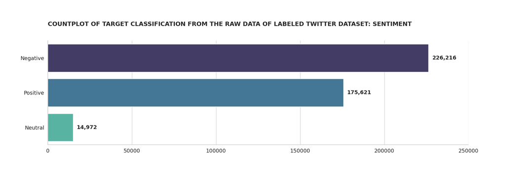

```python
plot_countplot(
  data=df, y='sentiment_label_description',
  title = 'Countplot of target classification from the raw data of labeled twitter dataset: Sentiment',
  height = 5,
);
```

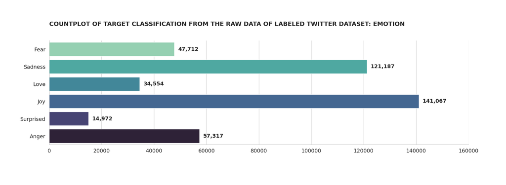

```python
plot_countplot(
  data=df, y='emotion_label_description',
  title='Countplot of target classification from the raw data of labeled twitter dataset: Emotion',
  height=5, palette=palette_a2
);
```

Casting attributes to the right datatype

```python
category_attribute_list = ['emotion_label_description', 'sentiment_label_description']
integer_attribute_list = ['emotion_label', 'sentiment_label']

for attribute in category_attribute_list:
  df[attribute] = df[attribute].astype('category')

for attribute in integer_attribute_list:
  df[attribute] = df[attribute].astype('int')
```

```python
df.info(verbose = True, show_counts = True)
```

```
<class 'pandas.core.frame.DataFrame'>
Index: 416809 entries, 0 to 416808
Data columns (total 5 columns):
 #   Column                       Non-Null Count   Dtype
---  ------                       --------------   -----
 0   text                         416809 non-null  object
 1   emotion_label                416809 non-null  int64
 2   emotion_label_description    416809 non-null  category
 3   sentiment_label              416809 non-null  int64
 4   sentiment_label_description  416809 non-null  category
dtypes: category(2), int64(2), object(1)
memory usage: 13.5+ MB
```

## Execution

### Data preprocessing

Making a data pipeline to:

Removing the username and non-alphabetical characters in the content to reduce noise and improve data quality

```python
class TextProcessorABC(ABC):
	def __init__(self, next_processor=None):
		self.next_processor = next_processor

	@abstractmethod
	def process(self, text: str) -> str:
		pass

	def set_next_processor(self, next_processor):
		self.next_processor = next_processor
		return self

	def process_next(self, text: str) -> str:
		if self.next_processor:
			return self.next_processor.process(text)
		return text
```

```python
class DenoiseProcessor(TextProcessorABC):
	def process(self, text: str) -> str:
		text = re.sub(r"@\w+", "", text)
		text = re.sub(r"[^a-zA-Z ]", "", text)
		text = re.sub(r"https\w+", "", text)
		text = re.sub(r"http\w+", "", text)
		text = text.strip()
		text = text.lower()
		return self.process_next(text)
```

```python
class LemmatizeProcessor(TextProcessorABC):
    def process(self, text: str):
        wordnet_lemmatizer = WordNetLemmatizer()
        tokenizer = TweetTokenizer()

        wordnet_pos_tag_map = {
            "J": wordnet.ADJ,
            "N": wordnet.NOUN,
            "V": wordnet.VERB,
            "R": wordnet.ADV,
        }

        tokens = tokenizer.tokenize(text)
        pos_tags = pos_tag(tokens)

        lemmatized_tokens = []
        for token, tag in pos_tags:
            wordnet_tag = wordnet_pos_tag_map.get(tag[0].upper())
            if wordnet_tag is None:
                lemmatized_tokens.append(token)
            else:
                lemmatized_tokens.append(
                    wordnet_lemmatizer.lemmatize(token, wordnet_tag)
                )

        processed_text = " ".join(lemmatized_tokens)
        return self.process_next(processed_text)
```

```python
class RemoveStopwordsProcessor(TextProcessorABC):
    def process(self, text: str):
        matcher = re.compile(
            r"|".join([rf"\b{word}\b" for word in stopwords.words("english")])
        )

        processed_text = " ".join(matcher.sub("", text).split())

        return self.process_next(processed_text)
```

Running the pipeline and exporting to csv to skip reprocessing of the dataset

```python
# Denoise then lemmatize
text_processor = DenoiseProcessor().set_next_processor(LemmatizeProcessor())

# Read the processed dataset if already exists
if os.path.isfile('data/dataset_processed.csv'):
  df = pd.read_csv('data/dataset_processed.csv')

else:
	df['text'] = df['text'].apply(lambda x: text_processor.process(x))

	# Save the processed data to csv
	df.to_csv('data/dataset_processed.csv', index=False)
```

```python
df.info()
```

```
<class 'pandas.core.frame.DataFrame'>
RangeIndex: 416809 entries, 0 to 416808
Data columns (total 5 columns):
 #   Column                       Non-Null Count   Dtype
---  ------                       --------------   -----
 0   text                         416809 non-null  object
 1   emotion_label                416809 non-null  int64
 2   emotion_label_description    416809 non-null  object
 3   sentiment_label              416809 non-null  int64
 4   sentiment_label_description  416809 non-null  object
dtypes: int64(2), object(3)
memory usage: 15.9+ MB
```

```python
df.head()
```

|  | text | emotion_label | emotion_label_description | sentiment_label | sentiment_label_description |
| --- | --- | --- | --- | --- | --- |
| 0 | i just feel really helpless and heavy hearted | 4 | fear | 0 | negative |
| 1 | ive enjoy be able to slouch about relax and un... | 0 | sadness | 0 | negative |
| 2 | i give up my internship with the dmrg and be f... | 4 | fear | 0 | negative |
| 3 | i dont know i feel so lose | 0 | sadness | 0 | negative |
| 4 | i be a kindergarten teacher and i be thoroughl... | 4 | fear | 0 | negative |

### Modeling

Initializing the primary variables

```python
x = np.array(df['text'])
y_sentiment = np.array(df['sentiment_label'])
y_emotion = np.array(df['emotion_label'])
```

TF-IDF Vectorizer to evaluate the importance of a word relative to the collection of documents by combining two metrics:

- **Term Frequency (TF)**: Measures how frequently a term appears in a document. It reflects the local importance of the term within a specific document.
- **Inverse Document Frequency (IDF)**: Measures how important a term is in the entire corpus. It decreases the weight of terms that appear frequently across many documents and increases the weight of terms that are rare.

```python
vectorizer = TfidfVectorizer(ngram_range=(1, 2), stop_words='english').fit(x)
```

Chi-squared test based feature selector to select the most relevant features for a model based on their relationship with the target variable.

- **Chi-Squared Test:** The Chi-squared test assesses whether the observed frequencies of features (terms) in the dataset differ significantly from expected frequencies. It measures the independence between features and the target variable.
- **Feature Selection with SelectKBest**: SelectKBest uses the Chi-squared test to rank features based on their statistical significance.SelectKBest selects the k features with the highest Chi-squared scores.

```python
selector_sentiment = SelectKBest(chi2, k=160000)
selector_emotion = SelectKBest(chi2, k=80000)
```

Defining a class to streamline the transformers

```python
class Transformer:
  def __init__(self, x):
    self.x = x

  def vectorizer(self):
    self.x = vectorizer.transform(self.x)
    return self

  def selector(self, selector):
    self.x = selector.transform(self.x)
    return self

  def get_value(self):
    return self.x
```

Splitting the training and testing data

```python
x_sentiment_train, x_sentiment_test, y_sentiment_train, y_sentiment_test = train_test_split(
  x, y_sentiment,
  test_size=0.25,
  random_state=42,
  stratify=y_sentiment, )

selector_sentiment.fit(
  vectorizer.transform(x_sentiment_train),
  y_sentiment_train, )

x_sentiment_train_selected = (
  Transformer(x_sentiment_train)
  .vectorizer()
  .selector(selector_sentiment)
  .get_value())

x_sentiment_test_selected = (
  Transformer(x_sentiment_test)
  .vectorizer()
  .selector(selector_sentiment)
  .get_value())
```

```python
x_emotion_train, x_emotion_test, y_emotion_train, y_emotion_test = train_test_split(
  x, y_emotion,
  test_size=0.25,
  random_state=42,
  stratify=y_emotion, )

selector_emotion.fit(
  vectorizer.transform(x_emotion_train),
  y_emotion_train, )

x_emotion_train_selected = (
  Transformer(x_emotion_train)
  .vectorizer()
  .selector(selector_emotion)
  .get_value())

x_emotion_test_selected = (
  Transformer(x_emotion_test)
  .vectorizer()
  .selector(selector_emotion)
  .get_value())
```

Visualizing the first 10 observations of vectorized data of the sentiment training data

```python
pd.DataFrame(
  vectorizer.transform(x_sentiment_train)[:10].toarray(),
  columns=vectorizer.get_feature_names_out(), )
```

|  | aa | aa blast | aa button | aa config | aa didnt | aa feel | aa finally | aa force | aa linkurl | aa meeting | ... | zyrtec feel | zz | zz bleh | zz logo | zzz | zzzz | zzzz know | zzzzzz | zzzzzzs | zzzzzzz |
| --- | --- | --- | --- | --- | --- | --- | --- | --- | --- | --- | --- | --- | --- | --- | --- | --- | --- | --- | --- | --- | --- |
| 0 | 0.0 | 0.0 | 0.0 | 0.0 | 0.0 | 0.0 | 0.0 | 0.0 | 0.0 | 0.0 | ... | 0.0 | 0.0 | 0.0 | 0.0 | 0.0 | 0.0 | 0.0 | 0.0 | 0.0 | 0.0 |
| 1 | 0.0 | 0.0 | 0.0 | 0.0 | 0.0 | 0.0 | 0.0 | 0.0 | 0.0 | 0.0 | ... | 0.0 | 0.0 | 0.0 | 0.0 | 0.0 | 0.0 | 0.0 | 0.0 | 0.0 | 0.0 |
| 2 | 0.0 | 0.0 | 0.0 | 0.0 | 0.0 | 0.0 | 0.0 | 0.0 | 0.0 | 0.0 | ... | 0.0 | 0.0 | 0.0 | 0.0 | 0.0 | 0.0 | 0.0 | 0.0 | 0.0 | 0.0 |
| 3 | 0.0 | 0.0 | 0.0 | 0.0 | 0.0 | 0.0 | 0.0 | 0.0 | 0.0 | 0.0 | ... | 0.0 | 0.0 | 0.0 | 0.0 | 0.0 | 0.0 | 0.0 | 0.0 | 0.0 | 0.0 |
| 4 | 0.0 | 0.0 | 0.0 | 0.0 | 0.0 | 0.0 | 0.0 | 0.0 | 0.0 | 0.0 | ... | 0.0 | 0.0 | 0.0 | 0.0 | 0.0 | 0.0 | 0.0 | 0.0 | 0.0 | 0.0 |
| 5 | 0.0 | 0.0 | 0.0 | 0.0 | 0.0 | 0.0 | 0.0 | 0.0 | 0.0 | 0.0 | ... | 0.0 | 0.0 | 0.0 | 0.0 | 0.0 | 0.0 | 0.0 | 0.0 | 0.0 | 0.0 |
| 6 | 0.0 | 0.0 | 0.0 | 0.0 | 0.0 | 0.0 | 0.0 | 0.0 | 0.0 | 0.0 | ... | 0.0 | 0.0 | 0.0 | 0.0 | 0.0 | 0.0 | 0.0 | 0.0 | 0.0 | 0.0 |
| 7 | 0.0 | 0.0 | 0.0 | 0.0 | 0.0 | 0.0 | 0.0 | 0.0 | 0.0 | 0.0 | ... | 0.0 | 0.0 | 0.0 | 0.0 | 0.0 | 0.0 | 0.0 | 0.0 | 0.0 | 0.0 |
| 8 | 0.0 | 0.0 | 0.0 | 0.0 | 0.0 | 0.0 | 0.0 | 0.0 | 0.0 | 0.0 | ... | 0.0 | 0.0 | 0.0 | 0.0 | 0.0 | 0.0 | 0.0 | 0.0 | 0.0 | 0.0 |
| 9 | 0.0 | 0.0 | 0.0 | 0.0 | 0.0 | 0.0 | 0.0 | 0.0 | 0.0 | 0.0 | ... | 0.0 | 0.0 | 0.0 | 0.0 | 0.0 | 0.0 | 0.0 | 0.0 | 0.0 | 0.0 |

10 rows × 1203932 columns

Visualizing the first 10 observations of selected features of the sentiment training data

```python
pd.DataFrame(
  selector_sentiment.transform(vectorizer.transform(x_sentiment_train))[:10].toarray(),
  columns=np.array(vectorizer.get_feature_names_out())[np.array(selector_sentiment.get_support())], )
```

|  | aa didnt | aa meeting | aaa | aaaa | aaaa want | aaaaall | aaaaall sort | aaaah | aardvarkartglass | aaron friend | ... | zum | zuo | zuo eagle | zusaks | zusaks work | zuu | zygote | zzzz | zzzz know | zzzzzzs |
| --- | --- | --- | --- | --- | --- | --- | --- | --- | --- | --- | --- | --- | --- | --- | --- | --- | --- | --- | --- | --- | --- |
| 0 | 0.0 | 0.0 | 0.0 | 0.0 | 0.0 | 0.0 | 0.0 | 0.0 | 0.0 | 0.0 | ... | 0.0 | 0.0 | 0.0 | 0.0 | 0.0 | 0.0 | 0.0 | 0.0 | 0.0 | 0.0 |
| 1 | 0.0 | 0.0 | 0.0 | 0.0 | 0.0 | 0.0 | 0.0 | 0.0 | 0.0 | 0.0 | ... | 0.0 | 0.0 | 0.0 | 0.0 | 0.0 | 0.0 | 0.0 | 0.0 | 0.0 | 0.0 |
| 2 | 0.0 | 0.0 | 0.0 | 0.0 | 0.0 | 0.0 | 0.0 | 0.0 | 0.0 | 0.0 | ... | 0.0 | 0.0 | 0.0 | 0.0 | 0.0 | 0.0 | 0.0 | 0.0 | 0.0 | 0.0 |
| 3 | 0.0 | 0.0 | 0.0 | 0.0 | 0.0 | 0.0 | 0.0 | 0.0 | 0.0 | 0.0 | ... | 0.0 | 0.0 | 0.0 | 0.0 | 0.0 | 0.0 | 0.0 | 0.0 | 0.0 | 0.0 |
| 4 | 0.0 | 0.0 | 0.0 | 0.0 | 0.0 | 0.0 | 0.0 | 0.0 | 0.0 | 0.0 | ... | 0.0 | 0.0 | 0.0 | 0.0 | 0.0 | 0.0 | 0.0 | 0.0 | 0.0 | 0.0 |
| 5 | 0.0 | 0.0 | 0.0 | 0.0 | 0.0 | 0.0 | 0.0 | 0.0 | 0.0 | 0.0 | ... | 0.0 | 0.0 | 0.0 | 0.0 | 0.0 | 0.0 | 0.0 | 0.0 | 0.0 | 0.0 |
| 6 | 0.0 | 0.0 | 0.0 | 0.0 | 0.0 | 0.0 | 0.0 | 0.0 | 0.0 | 0.0 | ... | 0.0 | 0.0 | 0.0 | 0.0 | 0.0 | 0.0 | 0.0 | 0.0 | 0.0 | 0.0 |
| 7 | 0.0 | 0.0 | 0.0 | 0.0 | 0.0 | 0.0 | 0.0 | 0.0 | 0.0 | 0.0 | ... | 0.0 | 0.0 | 0.0 | 0.0 | 0.0 | 0.0 | 0.0 | 0.0 | 0.0 | 0.0 |
| 8 | 0.0 | 0.0 | 0.0 | 0.0 | 0.0 | 0.0 | 0.0 | 0.0 | 0.0 | 0.0 | ... | 0.0 | 0.0 | 0.0 | 0.0 | 0.0 | 0.0 | 0.0 | 0.0 | 0.0 | 0.0 |
| 9 | 0.0 | 0.0 | 0.0 | 0.0 | 0.0 | 0.0 | 0.0 | 0.0 | 0.0 | 0.0 | ... | 0.0 | 0.0 | 0.0 | 0.0 | 0.0 | 0.0 | 0.0 | 0.0 | 0.0 | 0.0 |

10 rows × 160000 columns

Model evaluation visualizer

```python
def visualize_model_evaluation(
  data=None, x=None, y=None,
  palette=palette_a1, height=5,
  title=' ', subtitle=' ', description=' ',
  classification_report=' '):

  sns.set(style = 'whitegrid')

  sns.set(
    style='whitegrid',
    rc={'figure.figsize': (13,height)}, )

  g=sns.countplot(
    data=data, y=y,
    palette=palette,
    hue=y,
    legend=False, )

  g.set_ylabel(' \n\n')
  g.set_xlabel(' \n\n\n\n')

  g.set_title(
    f'\n\n\n{title}\n\n'.upper(),
    loc='left',
    fontdict=dict(
      fontsize=16,
      fontweight='bold', ), )

  g.set_yticks(g.get_yticks())
  g.set_yticklabels(
    [tick_label.get_text().title() for tick_label in g.get_yticklabels()],
    fontdict=dict(
      fontsize=14,
      fontweight='medium', ), )

  g.set_xticks(g.get_xticks())
  g.set_xticklabels(
    [tick_label.get_text().title() for tick_label in g.get_xticklabels()],
    fontdict=dict(
      fontsize=14,
      fontweight='medium', ), )

  plt.text(
    s=f'{subtitle}',
    alpha=0.5, x=0, y=1.05,
    horizontalalignment='left',
    transform=g.transAxes, )

  plt.text(
    s=f'{description}',
    alpha=0.5, x=0, y=-.18,
    verticalalignment='baseline',
    horizontalalignment='left',
    transform=g.transAxes, )

  for container in g.containers:
    labels = g.bar_label(
      container=container,
      padding=10,
      fmt=lambda x: f'{x / len(data) * 100:.1f}%', )

    for label in labels:
      label.set_fontsize(14)
      label.set_fontweight('bold')

  plt.text(
    s=' ', x=1.7, y=1,
    transform=g.transAxes, )

  plt.text(
    s=classification_report.upper(), x=1.1, y=0.25,
    alpha=0.8, transform=g.transAxes,
    fontdict=dict(fontfamily='monospace'))

  sns.despine()

  return g
```

#### Training the sentiment classifier

```python
model_sentiment = MultinomialNB()
```

Grid search and cross validation hyperparameter tuning to select the best parameters and yield better accuracy

```python
gridsearch_model_sentiment = GridSearchCV(
  estimator=model_sentiment,
  param_grid={'alpha': [0.02, 0.05, 0.1, 0.2, 0.3, 0.4, 0.8, 0.9, 1.0, 1.1, 1.2]},
  cv=5,
  scoring='accuracy', )

gridsearch_model_sentiment.fit(
  x_sentiment_train_selected,
  y_sentiment_train, )

gridsearch_model_sentiment.best_params_
```

```
{'alpha': 0.05}
```

```python
gridsearch_model_sentiment.best_score_
```

```
np.float64(0.9515524354591944)
```

```python
model_sentiment = gridsearch_model_sentiment.best_estimator_
```

```python
df_sentiment_results = pd.DataFrame({
  'actual_value': y_sentiment_test,
  'predicted_value': model_sentiment.predict(x_sentiment_test_selected)
})

df_sentiment_results['classification'] = df_sentiment_results.apply(
  lambda x:
    'true positive' if x['actual_value'] == 1 and x['predicted_value'] == 1 else
    'true negative' if x['actual_value'] == 0 and x['predicted_value'] == 0 else
    'true neutral' if x['actual_value'] == 2 and x['predicted_value'] == 2 else
    'false positive' if x['actual_value'] != 1 and x['predicted_value'] == 1 else
    'false negative' if x['actual_value'] != 0 and x['predicted_value'] == 0 else
    'false neutral' if x['actual_value'] != 2 and x['predicted_value'] == 2 else
    None
  , axis=1
)
```

Visualize model evaluation

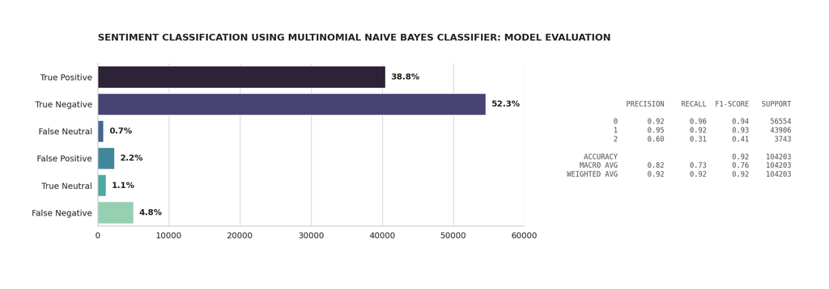

```python
classification_report_model_sentiment = classification_report(
  df_sentiment_results['actual_value'],
  df_sentiment_results['predicted_value'], )

visualize_model_evaluation(
  data=df_sentiment_results, y='classification',
  title='Sentiment classification using multinomial naive bayes classifier: model evaluation',
  height=5, palette=palette_a1,
  classification_report=classification_report_model_sentiment, );
```

Testing using the first 15 of the test split

```python
for x in x_sentiment_test[:15]:
	x = text_processor.process(x)
	x_transformed = Transformer([x]).vectorizer().selector(selector_sentiment).get_value()
	prediction = sentiment_label_description_map[model_sentiment.predict(x_transformed)[0]]
	print(f"[{prediction}] {x}")
```

```
[positive] i be feel so positive right now
[negative] i feel kind of insecure about it wear colour be more my thing
[positive] i know that because i feel so joyful every time
[negative] i know i need to meditate i be feel anxious and restless all day although my house sure get clean i be distract and unfocused during my yoga my balance be off it just wasnt work
[positive] i feel reassure that she do in fact trust and know me to some extent now and will do all that she can to prevent me from be mistreat
[positive] i feel about me work part time him support us and me take class full time
[neutral] i feel a bit strange write a blog post again after such a long absence
[positive] i need to get a tri bike it will help with my bike speed and plus i can feel cool
[negative] i feel absolutely distraught about this
[positive] i know what i would feel like if my gorgeous girl s
[negative] i feel like i should be more outraged about this
[negative] i not feel empty without them
[negative] i also feel i should say thanks maybe on behalf of nun whove be abuse
[negative] i feel reject for be too old and i don t think there be a woman alive that can stand that feel even if it be from a cold and unfeeling government entity
[negative] im still feel very uncertain about it
```

```python
response_list = [
  "I believe online anonymity encourages more honest and open communication, allowing users to express their true opinions",
  "In my view, online anonymity can lead to a significant increase in negative behaviors, such as trolling and cyberbullying, because users feel shielded from accountability.",
  "I think anonymity provides a double-edged sword; while it allows for free expression, it also creates an environment where people may engage in harmful or deceitful actions.",
  "Online anonymity empowers marginalized voices to speak out, but it also makes it difficult to identify and address harmful content effectively.",
  "I see online anonymity as a critical factor in fostering diverse discussions, but it also contributes to the spread of misinformation, as sources cannot always be verified.",
  "I think that online anonymity can lead to more genuine interactions in certain communities, but it may also reduce the quality of discourse by enabling users to avoid responsibility for their words.",
  "Anonymity online is essential for privacy, but it can also encourage users to engage in behavior they might avoid if their identity were known.",
  "In my opinion, the impact of online anonymity is largely context-dependent; it can promote both positive and negative behaviors depending on the platform and community norms.",
  "I believe online anonymity amplifies both the best and worst aspects of human behavior, providing a space for both creativity and cruelty.",
  "I think online anonymity allows people to connect more authentically, but it can also lead to a lack of trust and credibility in online interactions."
  "she is pretty",
  "jiya is pretty",
  "i think that it promotes cruelty",
  "nicely good"
]

test = pd.DataFrame({'text': response_list})
test['text'] = test['text'].apply(lambda x: text_processor.process(x))

model_sentiment.predict(
  Transformer(test['text'])
  .vectorizer()
  .selector(selector_sentiment)
  .get_value())
```

```
array([1, 1, 1, 0, 1, 1, 1, 1, 0, 1, 1, 0, 1])
```

#### Training the emotion classifier

```python
model_emotion = MultinomialNB()
```

Grid search and cross validation hyperparameter tuning to select the best parameters and yield better accuracy

```python
gridsearch_model_emotion = GridSearchCV(
  estimator=model_emotion,
  param_grid={'alpha': [0.02, 0.05, 0.1, 0.2, 0.3, 0.4, 0.8, 0.9, 1.0, 1.1, 1.2]},
  cv=5,
  scoring='accuracy', )

gridsearch_model_emotion.fit(
  x_emotion_train_selected,
  y_emotion_train, )

gridsearch_model_emotion.best_params_
```

```
{'alpha': 0.02}
```

```python
gridsearch_model_emotion.best_score_
```

```
np.float64(0.8764611014310081)
```

```python
model_emotion = gridsearch_model_emotion.best_estimator_
```

```python
df_emotion_results = pd.DataFrame({
  'actual_value': y_emotion_test,
  'predicted_value': model_emotion.predict(x_emotion_test_selected)
})

df_emotion_results['classification'] = df_emotion_results.apply(
  lambda x:
    'true sadness' if x['actual_value'] == 0 and x['predicted_value'] == 0 else
    'true joy' if x['actual_value'] == 1 and x['predicted_value'] == 1 else
    'true love' if x['actual_value'] == 2 and x['predicted_value'] == 2 else
    'true anger' if x['actual_value'] == 3 and x['predicted_value'] == 3 else
    'true fear' if x['actual_value'] == 4 and x['predicted_value'] == 4 else
    'true surprised' if x['actual_value'] == 5 and x['predicted_value'] == 5 else
    'false sadness' if x['actual_value'] != 0 and x['predicted_value'] == 0 else
    'false joy' if x['actual_value'] != 1 and x['predicted_value'] == 1 else
    'false love' if x['actual_value'] != 2 and x['predicted_value'] == 2 else
    'false anger' if x['actual_value'] != 3 and x['predicted_value'] == 3 else
    'false fear' if x['actual_value'] != 4 and x['predicted_value'] == 4 else
    'false surprised' if x['actual_value'] != 5 and x['predicted_value'] == 5 else
    None
  , axis=1
)
```

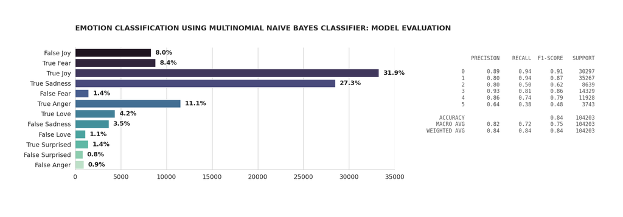

```python
classification_report_model_emotion = classification_report(
  df_emotion_results['actual_value'],
  df_emotion_results['predicted_value'], )

visualize_model_evaluation(
  data=df_emotion_results, y='classification',
  title='Emotion classification using multinomial naive bayes classifier: model evaluation',
  height=5, palette=palette_a1,
  classification_report=classification_report_model_emotion, );
```

```python
for x in x_emotion_test[1:16]:
	x = text_processor.process(x)
	x_transformed = Transformer([x]).vectorizer().selector(selector_emotion).get_value()
	prediction = emotion_label_description_map[model_emotion.predict(x_transformed)[0]]
	print(f"[{prediction}] {x}")
```

```
[fear] i be still feel a bit distraught but i have to try and get over it
[joy] i scoop up a card and gift wrap feel smug that i wouldn t be a part of the group gift er because i miss the deadline to contribute
[joy] i feel that be so important
[joy] i tell him that my expectation for that very important day be that i would feel special important and a priority of his
[fear] i approach them feel uncomfortable and out of place
[joy] a few month ago when i be teach
[sadness] i be feel sorry for myself from my recent viral illness i couldn t help but notice this beautiful sunset
[joy] i feel so energized and my mood be pleasant
[joy] im also use some of my favourite colour together they feel so rich and warm
[fear] im feel really agitate about horse right now and hopefully this will mean im go to make whichever horse i ride on in the future do what i want them to do
[joy] i feel content in a way i haven t experience before
[sadness] i have some concern about my preparation in the week before the run feel lethargic heavy and wasn t exactly confident that i d get near the time i post on the gold hellip race report jetty jetty redcliffe australia a class rsswidget href http www
[sadness] im addict i feel uber victimize wow it do seem i like to say uber a lot
[sadness] i feel like i m be punish everytime i shove one into my mouth
[sadness] i have a feeling i will be on the unpleasant end for sometime
```

```python
response_list = [
  "I believe online anonymity encourages more honest and open communication, allowing users to express their true opinions",
  "In my view, online anonymity can lead to a significant increase in negative behaviors, such as trolling and cyberbullying, because users feel shielded from accountability.",
  "I think anonymity provides a double-edged sword; while it allows for free expression, it also creates an environment where people may engage in harmful or deceitful actions.",
  "Online anonymity empowers marginalized voices to speak out, but it also makes it difficult to identify and address harmful content effectively.",
  "I see online anonymity as a critical factor in fostering diverse discussions, but it also contributes to the spread of misinformation, as sources cannot always be verified.",
  "I think that online anonymity can lead to more genuine interactions in certain communities, but it may also reduce the quality of discourse by enabling users to avoid responsibility for their words.",
  "Anonymity online is essential for privacy, but it can also encourage users to engage in behavior they might avoid if their identity were known.",
  "In my opinion, the impact of online anonymity is largely context-dependent; it can promote both positive and negative behaviors depending on the platform and community norms.",
  "I believe online anonymity amplifies both the best and worst aspects of human behavior, providing a space for both creativity and cruelty.",
  "I think online anonymity allows people to connect more authentically, but it can also lead to a lack of trust and credibility in online interactions."
]

test = pd.DataFrame({'text': response_list})
test['text'] = test['text'].apply(lambda x: text_processor.process(x))


model_emotion.predict(
  Transformer(test['text'])
  .vectorizer()
  .selector(selector_emotion)
  .get_value())
```

```
array([1, 1, 1, 1, 1, 1, 4, 1, 1, 1])
```

Saving the vectorizer, selector, and model locally

```python
joblib.dump(vectorizer, 'pkl/tfidf_vectorizer.pkl', compress=3)
joblib.dump(selector_sentiment, 'pkl/selector_sentiment.pkl', compress=3)
joblib.dump(selector_emotion, 'pkl/selector_emotion.pkl', compress=3)
joblib.dump(model_sentiment, 'pkl/model_sentiment.pkl', compress=3)
joblib.dump(model_emotion, 'pkl/model_emotion.pkl', compress=3)
```

```
['pkl/model_emotion.pkl']
```

### Model Evaluation with Local Dataset

Thread question: How would you describe your current feelings of happiness and hope as a member of the SPC community?

```python
df_spc_hope = pd.read_csv('./data/spc_hope_data.csv')
```

```python
df_spc_hope
```

|  | post_id | post_content | predicted_sentiment | predicted_emotion | true_sentiment | true_emotion | created_at |
| --- | --- | --- | --- | --- | --- | --- | --- |
| 0 | 21 | Horrible and underwhelmed | negative | sadness | negative | sadness | 2025-02-07 01:45:43 |
| 1 | 22 | Tired and dissatisfied | negative | anger | negative | anger | 2025-02-07 01:47:57 |
| 2 | 23 | Very Happy | positive | joy | positive | joy | 2025-02-07 01:50:02 |
| 3 | 24 | Fine and good. | positive | joy | positive | joy | 2025-02-07 01:50:10 |
| 4 | 25 | I'm happy with the stability of income and how... | positive | joy | positive | joy | 2025-02-07 01:50:18 |
| ... | ... | ... | ... | ... | ... | ... | ... |
| 96 | 124 | As an SPC student, the feelings of happiness a... | positive | joy | positive | joy | 2025-02-08 07:08:21 |
| 97 | 125 | It's very happy because of the teachers na bes... | positive | joy | positive | joy | 2025-02-08 07:29:08 |
| 98 | 126 | Satisfied and happier | positive | joy | positive | joy | 2025-02-08 07:51:36 |
| 99 | 127 | I feel motivated to study harder to achieve my... | positive | joy | negative | sadness | 2025-02-09 12:03:39 |
| 100 | 128 | Disappointed due to abysmally slow improvement... | negative | sadness | negative | anger | 2025-02-09 13:24:26 |

101 rows × 7 columns

#### Model Predictions

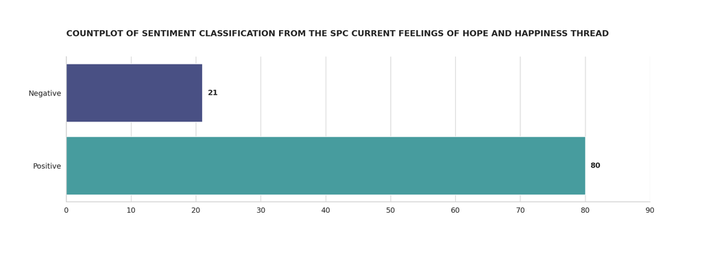

```python
plot_countplot(
  data=df_spc_hope, y='predicted_sentiment',
  title = 'Countplot of sentiment classification from the SPC current feelings of hope and happiness thread ',
  height = 5,
);
```

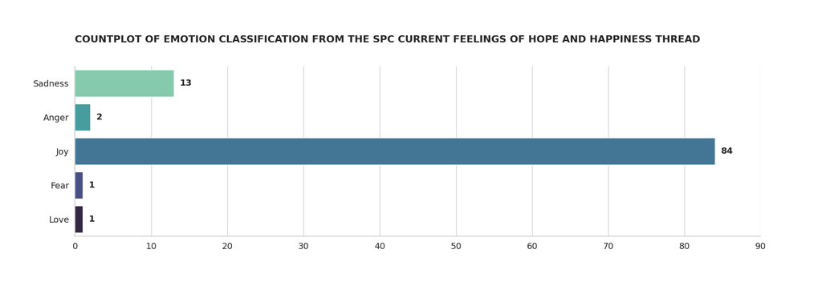

```python
plot_countplot(
  data=df_spc_hope, y='predicted_emotion',
  title='Countplot of emotion classification from the SPC current feelings of hope and happiness thread',
  height=5, palette=palette_a2
);
```

#### Ground Truth

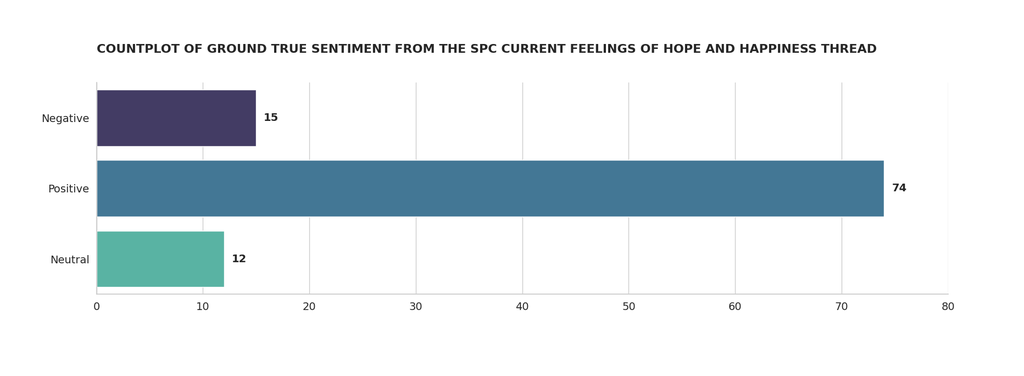

```python
plot_countplot(
  data=df_spc_hope, y='true_sentiment',
  title = 'Countplot of ground true sentiment from the SPC current feelings of hope and happiness thread ',
  height = 5,
);
```

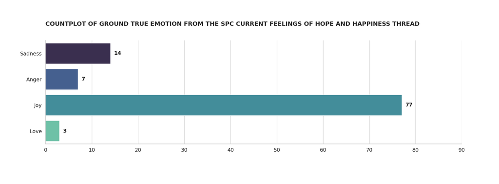

```python
plot_countplot(
  data=df_spc_hope, y='true_emotion',
  title = 'Countplot of ground true emotion from the SPC current feelings of hope and happiness thread ',
  height = 5,
);
```

#### Model Performance Evaluation

```python
df_spc_hope
```

|  | post_id | post_content | predicted_sentiment | predicted_emotion | true_sentiment | true_emotion | created_at |
| --- | --- | --- | --- | --- | --- | --- | --- |
| 0 | 21 | Horrible and underwhelmed | negative | sadness | negative | sadness | 2025-02-07 01:45:43 |
| 1 | 22 | Tired and dissatisfied | negative | anger | negative | anger | 2025-02-07 01:47:57 |
| 2 | 23 | Very Happy | positive | joy | positive | joy | 2025-02-07 01:50:02 |
| 3 | 24 | Fine and good. | positive | joy | positive | joy | 2025-02-07 01:50:10 |
| 4 | 25 | I'm happy with the stability of income and how... | positive | joy | positive | joy | 2025-02-07 01:50:18 |
| ... | ... | ... | ... | ... | ... | ... | ... |
| 96 | 124 | As an SPC student, the feelings of happiness a... | positive | joy | positive | joy | 2025-02-08 07:08:21 |
| 97 | 125 | It's very happy because of the teachers na bes... | positive | joy | positive | joy | 2025-02-08 07:29:08 |
| 98 | 126 | Satisfied and happier | positive | joy | positive | joy | 2025-02-08 07:51:36 |
| 99 | 127 | I feel motivated to study harder to achieve my... | positive | joy | negative | sadness | 2025-02-09 12:03:39 |
| 100 | 128 | Disappointed due to abysmally slow improvement... | negative | sadness | negative | anger | 2025-02-09 13:24:26 |

101 rows × 7 columns

```python
sentiment_label_encoding_map = {
	"negative": 0,
	"positive": 1,
	"neutral": 2
}

emotion_label_encoding_map = {
  'sadness': 0,
  'joy': 1,
  'love': 2,
  'anger': 3,
  'fear': 4,
  'surprised': 5,
}
```

```python
df_spc_hope['predicted_sentiment_encoded'] = df_spc_hope['predicted_sentiment'].apply(lambda x: sentiment_label_encoding_map[x])
df_spc_hope['true_sentiment_encoded'] = df_spc_hope['true_sentiment'].apply(lambda x: sentiment_label_encoding_map[x])
df_spc_hope['predicted_emotion_encoded'] = df_spc_hope['predicted_emotion'].apply(lambda x: emotion_label_encoding_map[x])
df_spc_hope['true_emotion_encoded'] = df_spc_hope['true_emotion'].apply(lambda x: emotion_label_encoding_map[x])
```

```python
df_spc_hope
```

|  | post_id | post_content | predicted_sentiment | predicted_emotion | true_sentiment | true_emotion | created_at | predicted_sentiment_encoded | true_sentiment_encoded | predicted_emotion_encoded | true_emotion_encoded |
| --- | --- | --- | --- | --- | --- | --- | --- | --- | --- | --- | --- |
| 0 | 21 | Horrible and underwhelmed | negative | sadness | negative | sadness | 2025-02-07 01:45:43 | 0 | 0 | 0 | 0 |
| 1 | 22 | Tired and dissatisfied | negative | anger | negative | anger | 2025-02-07 01:47:57 | 0 | 0 | 3 | 3 |
| 2 | 23 | Very Happy | positive | joy | positive | joy | 2025-02-07 01:50:02 | 1 | 1 | 1 | 1 |
| 3 | 24 | Fine and good. | positive | joy | positive | joy | 2025-02-07 01:50:10 | 1 | 1 | 1 | 1 |
| 4 | 25 | I'm happy with the stability of income and how... | positive | joy | positive | joy | 2025-02-07 01:50:18 | 1 | 1 | 1 | 1 |
| ... | ... | ... | ... | ... | ... | ... | ... | ... | ... | ... | ... |
| 96 | 124 | As an SPC student, the feelings of happiness a... | positive | joy | positive | joy | 2025-02-08 07:08:21 | 1 | 1 | 1 | 1 |
| 97 | 125 | It's very happy because of the teachers na bes... | positive | joy | positive | joy | 2025-02-08 07:29:08 | 1 | 1 | 1 | 1 |
| 98 | 126 | Satisfied and happier | positive | joy | positive | joy | 2025-02-08 07:51:36 | 1 | 1 | 1 | 1 |
| 99 | 127 | I feel motivated to study harder to achieve my... | positive | joy | negative | sadness | 2025-02-09 12:03:39 | 1 | 0 | 1 | 0 |
| 100 | 128 | Disappointed due to abysmally slow improvement... | negative | sadness | negative | anger | 2025-02-09 13:24:26 | 0 | 0 | 0 | 3 |

101 rows × 11 columns

```python
df_spc_hope['classification_sentiment'] = df_spc_hope.apply(
  lambda x:
    'true positive' if x['true_sentiment_encoded'] == 1 and x['predicted_sentiment_encoded'] == 1 else
    'true negative' if x['true_sentiment_encoded'] == 0 and x['predicted_sentiment_encoded'] == 0 else
    'true neutral' if x['true_sentiment_encoded'] == 2 and x['predicted_sentiment_encoded'] == 2 else
    'false positive' if x['true_sentiment_encoded'] != 1 and x['predicted_sentiment_encoded'] == 1 else
    'false negative' if x['true_sentiment_encoded'] != 0 and x['predicted_sentiment_encoded'] == 0 else
    'false neutral' if x['true_sentiment_encoded'] != 2 and x['predicted_sentiment_encoded'] == 2 else
    None
  , axis=1
)
```

```python
df_spc_hope['classification_emotion'] = df_spc_hope.apply(
  lambda x:
    'true sadness' if x['true_emotion_encoded'] == 0 and x['predicted_emotion_encoded'] == 0 else
    'true joy' if x['true_emotion_encoded'] == 1 and x['predicted_emotion_encoded'] == 1 else
    'true love' if x['true_emotion_encoded'] == 2 and x['predicted_emotion_encoded'] == 2 else
    'true anger' if x['true_emotion_encoded'] == 3 and x['predicted_emotion_encoded'] == 3 else
    'true fear' if x['true_emotion_encoded'] == 4 and x['predicted_emotion_encoded'] == 4 else
    'true surprised' if x['true_emotion_encoded'] == 5 and x['predicted_emotion_encoded'] == 5 else
    'false sadness' if x['true_emotion_encoded'] != 0 and x['predicted_emotion_encoded'] == 0 else
    'false joy' if x['true_emotion_encoded'] != 1 and x['predicted_emotion_encoded'] == 1 else
    'false love' if x['true_emotion_encoded'] != 2 and x['predicted_emotion_encoded'] == 2 else
    'false anger' if x['true_emotion_encoded'] != 3 and x['predicted_emotion_encoded'] == 3 else
    'false fear' if x['true_emotion_encoded'] != 4 and x['predicted_emotion_encoded'] == 4 else
    'false surprised' if x['true_emotion_encoded'] != 5 and x['predicted_emotion_encoded'] == 5 else
    None
  , axis=1
)
```

```python
df_spc_hope
```

|  | post_id | post_content | predicted_sentiment | predicted_emotion | true_sentiment | true_emotion | created_at | predicted_sentiment_encoded | true_sentiment_encoded | predicted_emotion_encoded | true_emotion_encoded | classification_sentiment | classification_emotion |
| --- | --- | --- | --- | --- | --- | --- | --- | --- | --- | --- | --- | --- | --- |
| 0 | 21 | Horrible and underwhelmed | negative | sadness | negative | sadness | 2025-02-07 01:45:43 | 0 | 0 | 0 | 0 | true negative | true sadness |
| 1 | 22 | Tired and dissatisfied | negative | anger | negative | anger | 2025-02-07 01:47:57 | 0 | 0 | 3 | 3 | true negative | true anger |
| 2 | 23 | Very Happy | positive | joy | positive | joy | 2025-02-07 01:50:02 | 1 | 1 | 1 | 1 | true positive | true joy |
| 3 | 24 | Fine and good. | positive | joy | positive | joy | 2025-02-07 01:50:10 | 1 | 1 | 1 | 1 | true positive | true joy |
| 4 | 25 | I'm happy with the stability of income and how... | positive | joy | positive | joy | 2025-02-07 01:50:18 | 1 | 1 | 1 | 1 | true positive | true joy |
| ... | ... | ... | ... | ... | ... | ... | ... | ... | ... | ... | ... | ... | ... |
| 96 | 124 | As an SPC student, the feelings of happiness a... | positive | joy | positive | joy | 2025-02-08 07:08:21 | 1 | 1 | 1 | 1 | true positive | true joy |
| 97 | 125 | It's very happy because of the teachers na bes... | positive | joy | positive | joy | 2025-02-08 07:29:08 | 1 | 1 | 1 | 1 | true positive | true joy |
| 98 | 126 | Satisfied and happier | positive | joy | positive | joy | 2025-02-08 07:51:36 | 1 | 1 | 1 | 1 | true positive | true joy |
| 99 | 127 | I feel motivated to study harder to achieve my... | positive | joy | negative | sadness | 2025-02-09 12:03:39 | 1 | 0 | 1 | 0 | false positive | false joy |
| 100 | 128 | Disappointed due to abysmally slow improvement... | negative | sadness | negative | anger | 2025-02-09 13:24:26 | 0 | 0 | 0 | 3 | true negative | false sadness |

101 rows × 13 columns

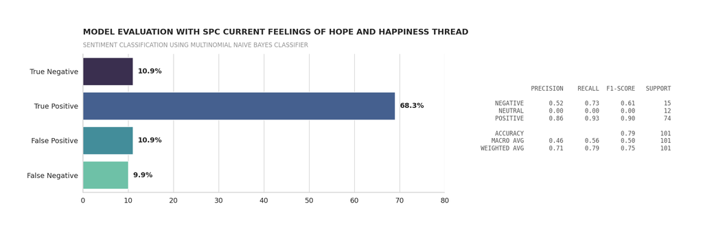

```python
spc_hope_classification_report_model_sentiment = classification_report(
  df_spc_hope['true_sentiment'],
  df_spc_hope['predicted_sentiment'], )

visualize_model_evaluation(
  data=df_spc_hope, y='classification_sentiment',
  title='Model evaluation with SPC Current Feelings of hope and happiness thread',
  subtitle="Sentiment classification using multinomial naive bayes classifier".upper(),
  height=5, palette=palette_a1,
  classification_report=spc_hope_classification_report_model_sentiment, );
```

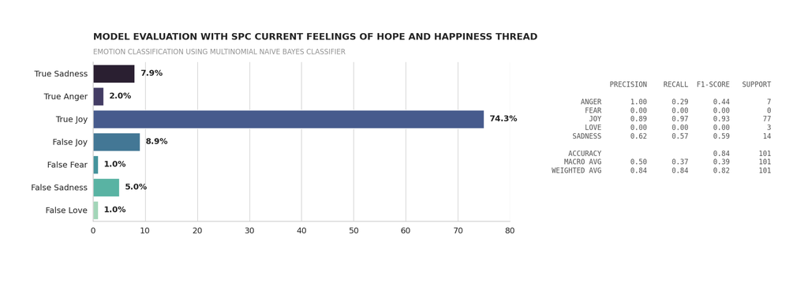

```python
spc_hope_classification_report_model_emotion = classification_report(
  df_spc_hope['true_emotion'],
  df_spc_hope['predicted_emotion'], )

visualize_model_evaluation(
  data=df_spc_hope, y='classification_emotion',
  title='Model evaluation with SPC Current Feelings of hope and happiness thread',
  subtitle="Emotion classification using multinomial naive bayes classifier".upper(),
  height=5, palette=palette_a1,
  classification_report=spc_hope_classification_report_model_emotion, );
```